# Spotify

Mason Ogden

February 1, 2019

I used one of my own playlists ‘Guitars and Keyboards’ for this analysis. My playlist has 18 artists with 73 songs from a total of 34 albums. To get my observed shuffled playlist, I clicked ‘SHUFFLE PLAY’ and then recorded the order in which the songs played, as well as the artist and the album.

Using the sample() function, I will randomly shuffle the ordered spotify playlist 1000 times and look for runs where the same artist was played 3 or more times in a row.

```r
nreps <- 1000
thousand_shuffles <- lapply(1:nreps, function(x) as.character(sample(spot$artist_code)))
# 'thousand_shuffles' is a list with 1000 entries; every entry being a list with 73 shuffled letters in it.
thousand_run_lengths <- rep(list(''), nreps) # Initialize list
for (i in 1:nreps) { # For each of the 1000 shuffled playlists in thousand_shuffles
  thousand_run_lengths[[i]] <- rle(thousand_shuffles[[i]])$lengths # Get the lengths of the longest run of songs for every artist
}
observed_run_length <- rle(as.character(spot_shuffled$artist_code))$lengths  # Get run lengths for the playlist shuffled by spotify
obs_num_3_or_more <- sum(observed_run_length >= 3) # Count how many of those spotify run lengths were 3 songs or longer
sim_num_3_or_more <- rep(list(''), nreps) # Initialize list
for (j in 1:nreps) { # For each of the 1000 vectors of run lengths
  sim_num_3_or_more[[j]] <- sum(thousand_run_lengths[[j]] >= 3) # Calculate how many runs were 3 songs or longer for each shuffle
}
sim_num_3_or_more <- unlist(sim_num_3_or_more) # Turn the list of runs into one long vector
mean_sim_run_length <- mean(sim_num_3_or_more)# Find the mean length  of all simulated runs
```

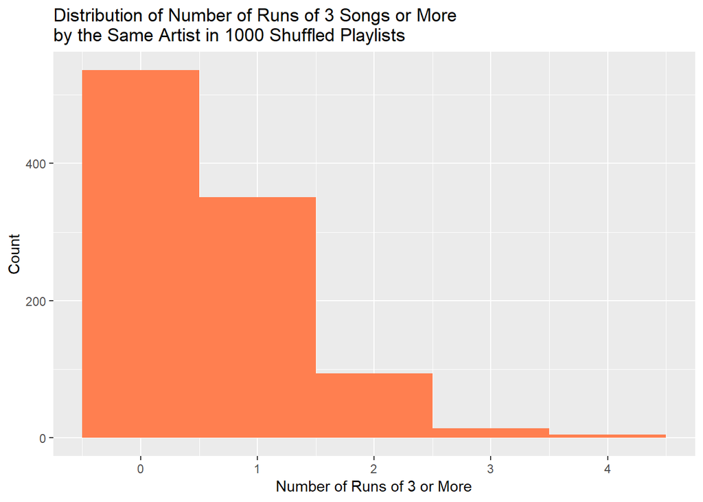

```r
sim_3_data <- data.frame(value=sim_num_3_or_more)
names(sim_3_data) <- 'num_3_or_more'
ggplot(sim_3_data, aes(x=num_3_or_more)) +
  geom_histogram(binwidth=1, fill='coral') +
  xlab('Number of Runs of 3 or More') +
  ylab('Count') +
  ggtitle('Distribution of Number of Runs of 3 Songs or More \nby the Same Artist in 1000 Shuffled Playlists')
```

So, I know that there were 3 runs of 3 or more in my playlist that was shuffled by Spotify. What is the probability of getting this many runs of at least 3 if the playlist order was random?

```r
sim_p_value <- sum(sim_num_3_or_more >= obs_num_3_or_more) / nreps
sim_p_value
```

```
## [1] 0.019
```